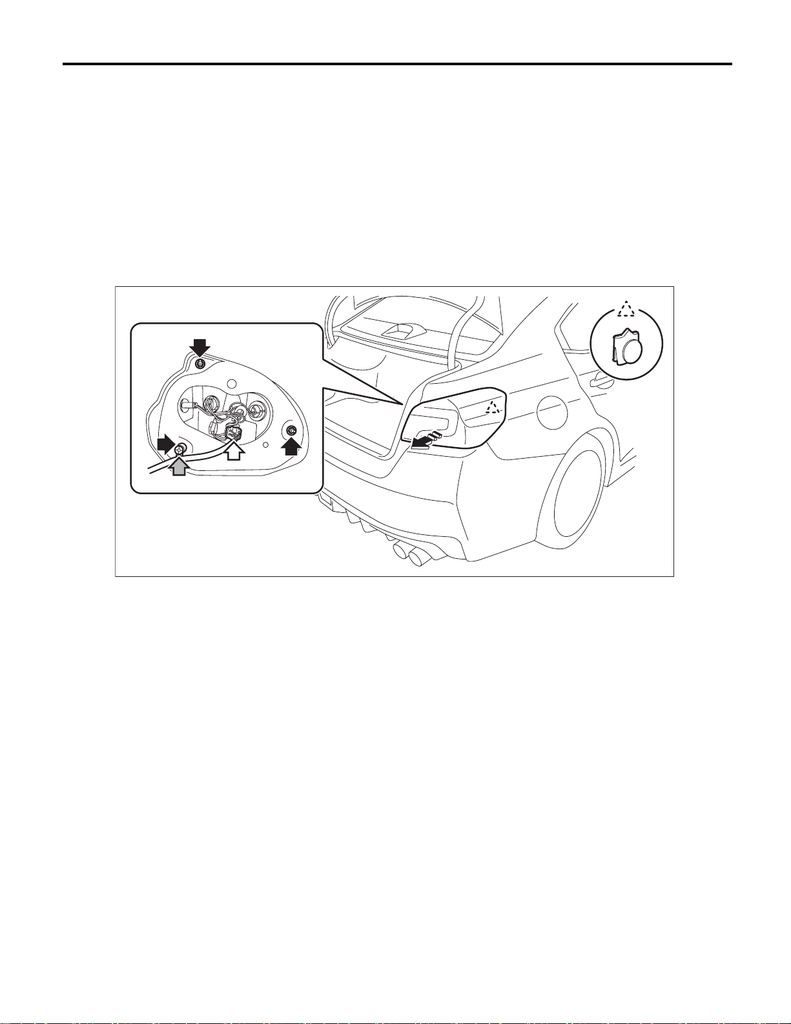

LI-49

Rear Combination Light Assembly

LIGHTING SYSTEM

25.Rear Combination Light Assembly

A: REMOVAL

1) Disconnect the ground cable from battery. <Ref. to NT-5, BATTERY, NOTE, Note.>

NOTE:

For models other than STI model, disconnect the ground terminal from battery sensor.

2) Remove the trunk room trim. <Ref. to EI-95, REMOVAL, Trunk Room Trim.>

3) Remove the light assembly - rear combination.

(1) Remove the harness clip and connector.

(2) Release the nuts and clips, then remove the light assembly - rear combination.

CAUTION:

Be careful not to damage the clips.

B: INSTALLATION

1) Replace the gasket - rear combination with a new part.

2) Install the light assembly - rear combination.

CAUTION:

Be careful not to catch the harness in between the parts.

Tightening torque:

4.5 N·m (0.5 kgf-m, 3.3 ft-lb)

3) Install the trunk room trim.

4) Connect the battery ground terminal. <Ref. to NT-5, BATTERY, NOTE, Note.>

NOTE:

For models other than STI model, connect the ground terminal to battery sensor.

LI-01729

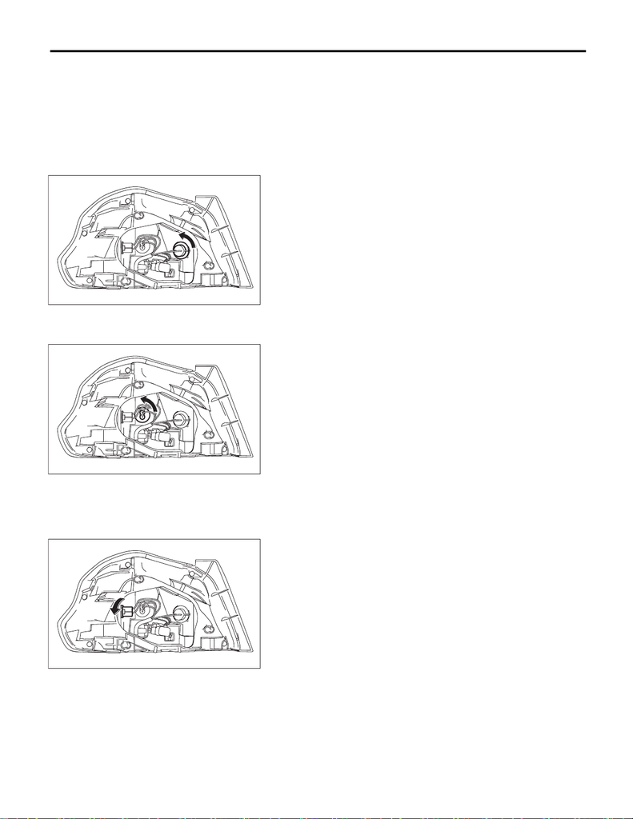

LI-50

Rear Combination Light Assembly

LIGHTING SYSTEM

C: DISASSEMBLY

CAUTION:

Use a dry clean cloth so that no grease or water adheres to the glass portion of the bulb.

NOTE:

Since the LED type is a non-disassembled part, it cannot be removed.

1. TURN SIGNAL LIGHT BULB

Rotate the bulb socket in the direction of arrow shown in the figure to remove the turn signal light bulb.

2. BACK-UP LIGHT BULB

Rotate the bulb socket in the direction of arrow shown in the figure to remove the back-up light bulb.

3. SIDE MARKER LIGHT BULB

2) Rotate the bulb socket in the direction of arrow shown in the figure to remove the side marker light bulb.

LI-01744

LI-01743

LI-01745

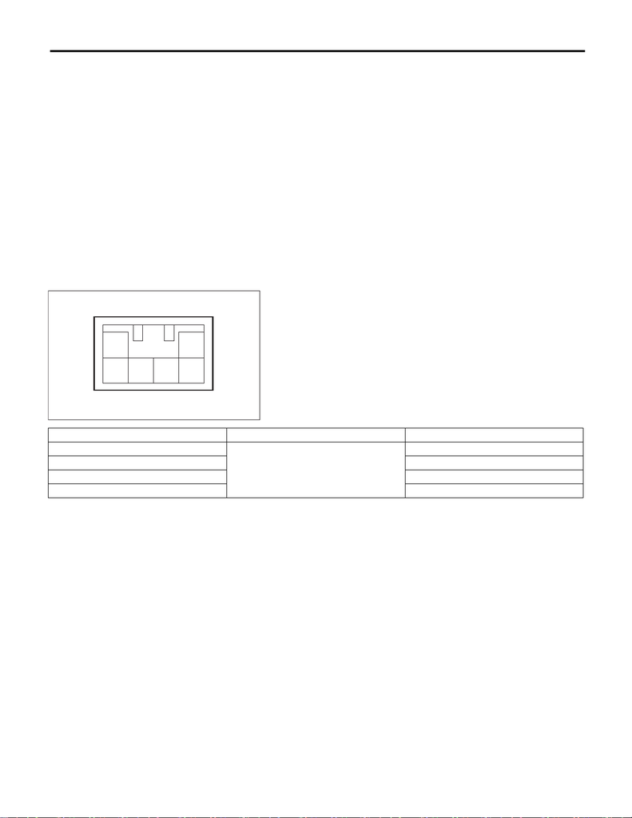

LI-51

Rear Combination Light Assembly

LIGHTING SYSTEM

D: ASSEMBLY

CAUTION:

Use a dry clean cloth so that no grease or water adheres to the glass portion of the bulb.

1. TURN SIGNAL LIGHT BULB

1) Install the turn signal light bulb.

2) Install the bulb socket.

2. BACK-UP LIGHT BULB

1) Install the back-up light bulb.

2) Install the bulb socket.

3. SIDE MARKER LIGHT BULB

1) Install the side marker light bulb.

2) Install the bulb socket.

E: INSPECTION

1) Apply battery voltage between the connector terminals to check the lighting condition of the light.

2) Replace the harness and bulb if it is found defective.

LI-01727

2 1

6 5 4 3

Terminal No. Inspection conditions Specification

6 (+) — 2 (–)

Apply battery voltage.

Stop light on

4 (+) — 2 (–) Tail / side marker light on

3 (+) — 2 (–) Turn signal light on

1 (+) — 2 (–) Back-up light on